# teea_session_7

N.Paterno

8/13/2021

Today was our ‘extra’ session to get a better grasp on paths and git/github. For the first majority of the session, we focused on paths and Git.

## Git

Git is a version control system (software) that we use to keep track of changes we make to our code. Really, it can be any type of file but it is almost always used for code. When we tell is to, Git will take a snapshot of our folder (project) that we can revert back to when wanted.

To accomplish this, we worked in the Git BASH. BASH is an acronym for Born Again SHell. A shell is a terminal application that is used to communicate with the operating system via commands. Before visual interfaces (like Windows, Mac OS, iOS, Android, etc), all computer users interacted with a computer via a terminal program. Using the search bar on the lower left side of the screen, we launch the program by searching for “git bash”. Initialy it will look like this:

[figure not shown]

A blank Git BASH terminal

The first line in my terminal is “nicho@Nick-Laptop MINGW64 ~”. The first part is “user@device-name” where *user* is your username for the computer and *device-name* is the name your computer has. Next is “MINGW64” this will be the same on any Windows computer. It is just the name of the platform running our BASH terminal. The “~” at the end is the current working directory. That is also listed in the menu bar across the top of the window “C/Users/nicho”.

The process we walked through was: navigating to our desktop, creating a folder, creating a file in that folder, initialize a git repository, edit the file multiple times, commit each change (take snapshots) and revert back to a previous change.

The first step is to navigate to the desktop. We run the command *ls* to see a list of files in the current working directory. Here is the list of my initial working directory (sometimes called the home directory).

[figure not shown]

Results of running the ‘ls’ command in the BASH terminal.

Since the “Desktop” is one of the files, I can do the next step from here. On your computer, the “Desktop” was a part of your OneDrive. You would run the command *cd OneDrive* and then run *cd Desktop*. Here is what happens after running *cd Desktop*.

[figure not shown]

Results of changing into the Desktop directory

At the bottom of the BASH, I see “~/Desktop”; yours should read “~/OneDrive/Desktop”. This is where we’ll create our folder. We do this with the command *mkdir folder-name*, followed by *ls* to see that the folder was created. “mkdir” is “make directory”.

[figure not shown]

Creating a new folder in the BASH terminal.

Next, we’ll move into that folder with the *cd* command.

[figure not shown]

Moving into the new folder.

Now we’re ready to create a new file. The command to create a file is *touch*. Again, we follow with *ls* to make sure the file was created.

[figure not shown]

Creating a new file with the touch command.

Next, we navigated to that file in the File Explorer and opened it in Notepad to make our edits.

[figure not shown]

Opening the file with Notepad.

Note that your screen might look slightly different here since I’ve got Windows 11 and they change the user interface a bit. The file I created “readme.txt” is a common file to have in a code repository. It usually explains what the project is, how to navigate the files, etc. I’ll add one line of ‘code’: “This is a readme file.” and then save using control-s.

[figure not shown]

Initial edit of the readme file.

Now we’ll navigate back to our BASH terminal. We need to initialize our Git repository (tell the computer we want to track changes) and commit the changes we’ve made to this file (take a snapshot of the folder). In the BASH we’ll run the command *git init* to initialize the repository. Note that our BASH line will now end in “(main)”, which is the name of the branch we are on. A branch is like a timeline for your folder; we’ll talk more about these at a later date.

Then we’ll run *git add readme.txt* to tell git to track this file. Then *git commit -m “Initial commit”* to take our snapshot. *git commit* is the command to take a snapshot, *-m* is a tag that says we want to leave a message with the commit, *Initial commit* is the message.

[figure not shown]

Initializing and adding the readme to tracking.

[figure not shown]

Committing the changes we made to the readme file.

Now we’ll go back to Notepad and add another line to our readme file. This time I’ll say “This is my second edit”.

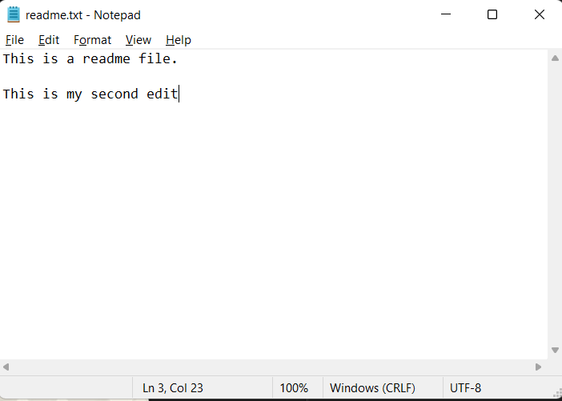

Second edit of the readme file.

Now we commit those changes.

[figure not shown]

Our second commit.

If we want to see a list of all the changes we’ve made since starting our repository we run the command *git reflog*.

[figure not shown]

The reference log of our repository so far.

Let’s say we don’t like the second edit. We can revert to the previous snapshot using *git reset*.

[figure not shown]

Resetting to the first commit.

In this command, the “HEAD@{1}” tells git to move the head of the project (the visible snapshot) to be 1 commit back from where we currently are. “HEAD@{1}” will point to a different commit everytime we make a new commit. The yellow numbers that we see at the start of each line at git hashes, a unique sequence of characters that identifies that commit. These values don’t change for a given commit. The flag “–hard” tells git to do a ‘hard’ reset, meaning that it will revert back to the previous point and delete any changes that were not saved. Opening up the readme file should show that the second edit is no longer there, only the first line.

## RStudio with Git

For the last bit we started to connect the dots between RStudio projects and git repositories. When we start a new project in RStudio, we are given the open to use version control via a checkbox to “Create a git repository”.

[figure not shown]

RStudio project set up with the box checked to use version control.

By checking this box, we’re essentially telling R to make a new folder (*mkdir test_folder*) and then initialize a repository in that folder(*cd test_folder* followed by *git init*).

Now the environment pane of RStudio will have a “Git” tab. When we make changes to a file in our project folder they will appear here.

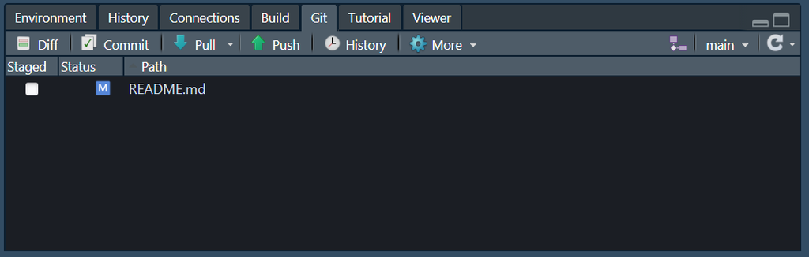

The git pane showing a change to the readme file.

Checking the box to the left of the file is equivalent to running *git add README.md* in the BASH terminal.

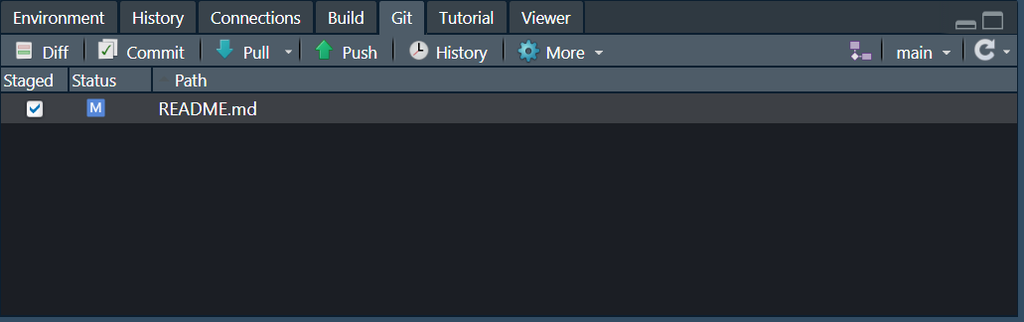

Staging a file to be committed.

Pressing commit will bring up a new window showing the changes made to the file and with a space to add our commit message. Doing so and pressing commit is equivalent to running *git commit -m “Updated README”* in the BASH terminal.

[figure not shown]

Commiting via RStudio.

RStudio provides us with a visual, interactive way to use git instead of using the BASH terminal. If you feel more comfortable with the BASH terminal, you can still run all the commands in the “Terminal” tab which is part of your “Console” pane.

So far, everything only exists on your local (physical) computer. We can connect an existing Git repository to a GitHub repository. This will allow us to *push* and *pull* snapshots to the cloud. Let’s do this now with our test_folder. First, we’ll create the new repository in GitHub with the same name as our folder. Here is the resulting screen:

[figure not shown]

Creating a new repository in GitHub.

Now we’ll go back to the BASH terminal and run the code on the lower half of that screen. This will create a connection between our computer and the cloud and then push the current snapshot to the cloud.

[figure not shown]

Adding a remote repository.

This means we can actually use Git/GitHub completely independent of RStudio! The **advantage** to using RStudio is the visual/interactive interface. It allows us to use buttons instead of memorizing commands.

## Additional resources for learning Git and Paths

- Video: [An introduction to git and github](https://youtu.be/MJUJ4wbFm_A)
- [Happy git with R](https://happygitwithr.com)
- [Oh Shit, Git !?!](https://ohshitgit.com)